[Статьи]

# Увеличение мощности ГТУ адиабатическим охлаждением воздуха

Новость ТАСС от 17.07.2024:

> "Системный оператор" сообщил, что абсолютный исторический рекорд потребления мощности в ОЭС Юга составил 20 954 МВт. Это на 4 МВт больше предыдущего исторического максимума потребления, достигнутого 13 января 2024 года. Достижение рекордных показателей потребления летом в этой энергосистеме обусловлено наплывом туристов в связи с отпускным сезоном и повсеместным использованием энергоемких приборов - кондиционеров, холодильного оборудования, пояснили в СО ЕЭС.

Согласно приведённой выше новости потребление электроэнергии летом превысило потребление электроэнергии зимой на 0,02%. Разве это повод для беспокойства?

Проблема заключается в том, что в тёплый период времени года генерирующие возможности электростанций, в состав которых входят газовые и (или) паровые турбины, снижаются по сравнению с холодным временем года. Причин несколько.

Во-первых, с повышением температуры окружающего воздуха растёт температура воды, охлаждающей конденсатор паротурбинной установки (ПТУ), что приводит к увеличению давления за последней ступенью паровой турбины (ухудшению вакуума), уменьшению теплоперепада в паровой турбине и снижению мощности ПТУ.

Во-вторых, с повышением температуры окружающего воздуха его плотность уменьшается, значит при неизменном объёмном расходе воздуха через компрессор газотурбинной установки (ГТУ) его массовый расход снижается. С уменьшением массового расхода воздуха снижается необходимый для "проталкивания" продуктов сгорания через газовую турбину (ГТ) перепад давления, что приводит к уменьшению давления перед ГТ и, как следствие, теплоперепада в ГТ. [Мощность ГТ]=[Массовый расход]*[Теплоперепад]. Снижение массового расхода рабочего тела и теплоперепада ГТ приводит к уменьшению мощности ГТУ.

В-третьих (для парогазовых установок - ПГУ), уменьшение массового расхода выхлопных газов ГТУ ведёт к снижению производительности вырабатывающего для ПТУ пар котла-утилизатора (КУ), что влечёт за собой уменьшение мощности ПТУ.

В жаркий период времени года (например, при температуре окружающего воздуха +35 С) номинальная мощность блока ПГУ становится ниже более чем на 15% по сравнению с номинальной мощностью блока при условиях ИСО (температура воздуха 15 С, давление 101,3 кПа, относительная влажность 60%).

Проблему с дефицитом электрической мощности в период экстремально высоких температур (ПЭВТ) можно решить либо строительством новых энергоблоков (при этом увеличивая долю блоков, которые из-за избытка располагаемой электрической мощности в холодный период времени года будут простаивать), либо внедряя на существующих блоках технические решения, позволяющие снизить величину падения их располагаемой электрической мощности при повышении температуры окружающего воздуха, либо комбинацией двух способов.

В данной статье рассматривается одно из таких технических решений - адиабатическое охлаждение поступающего в компрессор ГТУ воздуха.

В поток воздуха подаётся вода (впрыскивается или воздух пропускается через смоченную ткань), вода испаряется, забирая тепло у воздуха, что приводит к его охлаждению. Чем ниже относительная влажность воздуха и выше его температура тем на большую величину его можно охладить.

Более подробно об адиабатическом охлаждении см. [1]. При проведении расчётов будут использованы ранее разработанные инструменты (см. [2]).

Исходные данные:

1. Температура (t_нв), давление (p_нв=101,3 кПа), относительная влажность (RH_нв) наружного воздуха.
2. Предельная относительная влажность воздуха на выходе из системы адиабатического охлаждения (примем RH_макс = 95%).
3. Относительную мощность ГТУ при условиях ИСО примем за единицу.
4. При увеличении температуры окружающего воздуха с 15 С до 40 С падение мощности ГТУ составляет 18% (относительная мощность падает с 1,00 до 0,82).
5. Увеличение относительной влажности воздуха с 50% до 100% приводит к росту мощности ГТУ не более чем на 0,4%. Ввиду малости данный фактор учитываться не будет.

```python
from wetairprops import calc_t_wb, calc_d, calc_dens_d  # см. [2]
import numpy as np
```

```python
RH_макс = 0.95  # относительная влажность воздуха на выходе адиабатической системы охлаждения
p = 101325  # нормальное атмосферное давления, Па
```

```python
ts = np.linspace(15, 40)  # рассматриваемый диапазон температур окружающего воздуха
RHs = np.array([0.5, 0.6, 0.7, 0.8])  # рассматриваемые значения относительной влажности
```

```python
# Относительное изменение мощности при увеличении температуры окружающего воздуха от 15 С до 40 C
dN_15_40 = -0.18
def fdN(dt):
    return dN_15_40 / (40 - 15) * dt
```

```python
# Изменение мощности ГТУ при уменьшении температуры воздуха на 1 С, %
fdN(-1) * 100  # %
```

```
0.72
```

```python
# Формирование массивов исходных данных
ts_охл = np.array([[calc_t_wb(t, RH, p, RH_макс) for RH in RHs] for t in ts])
dts = ts_охл - ts[..., None]
```

```python
import matplotlib.pyplot as plt  # библиотека для построения графиков
plt.rcParams['font.size'] = 12.0
```

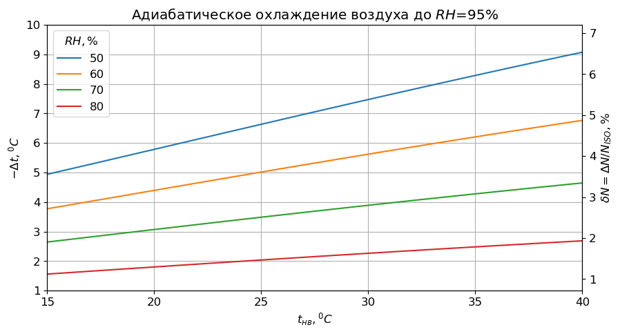

```python
fig, ax = plt.subplots(figsize = (10,5))
ax.set_title("Адиабатическое охлаждение воздуха до $RH$=95%");
ax.set_xlabel('$t_{нв}, ^0C$'); ax.set_ylabel(r'$-\Delta t, ^0C$')
ax.grid(); ax.set_xlim(ts[0], ts[-1]); ax.set_ylim(1,10);
ax2 = ax.twinx(); ax2.set_ylabel(r'$\delta N = \Delta N/N_{ISO}, \%$')
ax2.set_ylim(fdN(-1)*100, fdN(-10)*100);
ax.plot(ts, -dts);
ax.legend(np.int8(RHs * 100), title = r'$RH, \% $');
```

```python
# Относительная мощность ГТУ без системы охлждения при различных температурах наружного воздуха
Ns_0 = np.array([1 + fdN(t - 15) for t in ts])
# Относительная мощность ГТУ с системой охлаждения при различных отностельной влажности
# температуре наружного воздуха
Ns = np.array([[N_0 + fdN(dt) for dt in dtts] for N_0, dtts in zip(Ns_0, dts)])
```

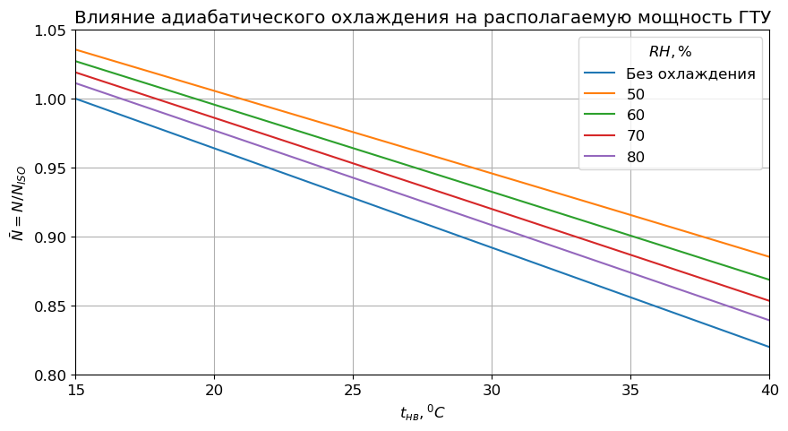

```python
fig, ax = plt.subplots(figsize = (10,5))
ax.set_title("Влияние адиабатического охлаждения на располагаемую мощность ГТУ");
ax.set_xlabel('$t_{нв}, ^0C$'); ax.set_ylabel(r'$\bar{N} = N / N_{ISO}$')
ax.grid(); ax.set_xlim(ts[0], ts[-1]); ax.set_ylim(0.8, 1.05);
ax.plot(ts, Ns_0); ax.plot(ts, Ns);
leg = ['Без охлаждения'] + list(np.int8(RHs * 100))
ax.legend(leg, title = r'$RH, \% $');
```

```python
# Массовый расход воды на адиабатическое охлаждение в грамм на кг сухого воздуха
gs = np.array([[calc_d(t_охл, RH_макс) - calc_d(t, RH) for RH, t_охл in zip(RHs, tts_охл)]
                for t, tts_охл in zip(ts, ts_охл)])
```

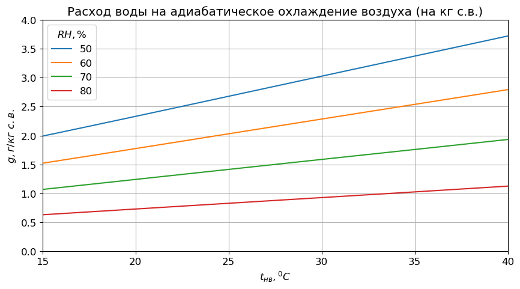

```python
fig, ax = plt.subplots(figsize = (10,5))
ax.set_title("Расход воды на адиабатическое охлаждение воздуха (на кг с.в.)");
ax.set_xlabel('$t_{нв}, ^0C$'); ax.set_ylabel(r'$g, г/кг\ с.в.$')
ax.grid(); ax.set_xlim(ts[0], ts[-1]); ax.set_ylim(0, 4 );
#ax2 = ax.twinx(); ax2.set_ylabel(r'$\delta N, \%$')
#ax2.set_ylim(fdN(-1)*100, fdN(-10)*100);
ax.plot(ts, gs);
ax.legend(np.int8(RHs * 100), title = r'$RH, \% $');
```

```python
# Проверка 1
t = 40; RH = 0.7
calc_d(calc_t_wb(t, RH, p, RH_макс), RH_макс) - calc_d(t, RH) - gs[-1][2]
```

```
0.0
```

```python
# Проверка 2
n=20; t = ts[n]; RH = 0.5
calc_d(calc_t_wb(t, RH, p, RH_макс), RH_макс) - calc_d(t, RH) - gs[n][0]
```

```
0.0
```

Пересчитаем расход воды на кг влажного воздуха перед системой адиабатического охлаждения.

```python
gs_вв = np.array([[ g / (1 + calc_d(t, RH)/ 1000) for g, RH in zip(ggs, RHs)]
                for t, ggs in zip(ts, gs)])
```

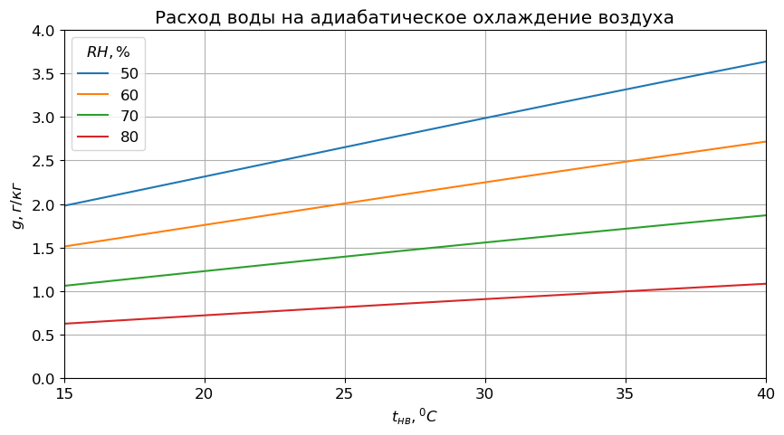

```python
fig, ax = plt.subplots(figsize = (10,5))
ax.set_title("Расход воды на адиабатическое охлаждение воздуха");
ax.set_xlabel('$t_{нв}, ^0C$'); ax.set_ylabel(r'$g, г/кг$')
ax.grid(); ax.set_xlim(ts[0], ts[-1]); ax.set_ylim(0, 4 );
ax.plot(ts, gs_вв);
ax.legend(np.int8(RHs * 100), title = r'$RH, \% $');
```

Для того чтобы определить требуемый расход воды на систему адиабатического охлаждения воздуха для конкретной ГТУ:

1. Найти M - массовый расход воздуха через компрессор ГТУ для режима работы при температуре наружного воздуха равной температуре воздуха на выходе из системы адиабатического охлаждения, кг/с. Обычно производители ГТУ предоставляется информация о расходе выхлопных газов на разных режимах работы ГТУ. Для того, чтобы найти массовый расход воздуха следует из массового расхода выхлопных газов вычесть массовый расход топлива. Данные по массовому расходу топлива для ГТУ различной мощности и КПД приведены в [3].
2. Расход воды (в граммах в секунду) на систему адиабатического охлаждения воздуха находится по формуле:

G = g * M,  
где g - расход воды на кг воздуха, г/кг (см. график выше), М - расход воздуха через компрессор ГТУ, кг/с.

Используя приведённые выше графики приблизительно определим расход воды на адиабатическое охлаждение воздуха для ГТУ мощностью 160 МВт (при условиях ИСО) при параметрах наружного воздуха t_нв = 40 C, RH = 50%, p = 101,3 кПа. Примем:

1. Массовый расход выхлопных газов на 1 МВт при условиях ИСО составляет 3,31 кг/с. Таким образом для ГТУ мощностью 160 МВт расход выхлопных газов 530 кг/с.
2. При увеличении температуры окружающего воздуха с 15 С до 40 С массовый расход выхлопных газов уменьшается на 10%.

Из первого графика найдём, что температура воздуха за счёт охлаждения уменьшится на 9 С до 31 С.

```python
N_ISO = 160  # мощность ГТУ при условиях ИСО, МВт
M_вг_ISO = 530  # расход выхлопных газов при условиях ИСО, кг/с
M_вг_ISO / N_ISO  # кг/с/МВт
```

```
3.3125
```

Из п. 2 следует, что массовый расход выхлопных газов при температуре t_нв = 31 С имеет величину

```python
# Массовый расход выхлопных газов ГТУ при t_нв = 40 С, кг/с
M_вг_40 = M_вг_ISO * (1 - 0.1 * (31 - 15) / (40 - 15))
M_вг_40  # кг/с
```

```
496.08
```

Из последнего графика находим расход воды на кг воздуха 3,7 г/кг.

```python
g = 3.7  # г на кг воздуха на входе в систему адиабатического охлаждения
```

Расход воды на систему адиабатического охлаждения при t_нв = 40 С, RH_нв = 50% составит

```python
G = M_вг_40 * g
G, G * 3600 / 1e6
# г/c, т/ч
```

```
(1835.496, 6.607785600000001)
```

В вышеприведённой упрощённой методике не учитывалось, что расход выхлопных газов выше расхода воздуха на входе в ГТУ на величину расхода топлива, так же не учитывалось увеличение за счёт расхода воды массового расхода воздуха на входе в ГТУ.

### Заключение

При адиабатическом охлаждении воздуха увеличивается массовый расход поступающих в КУ выхлопных газов ГТУ, паропроизводительность КУ возрастает, в конденсатор ПТУ приходит больше пара, что приводит к увеличению давления за последней ступенью ПТУ.

Поэтому перед тем как принять решение о применении системы адиабатического охлаждения необходимо убедиться, что при увеличенном расходе пара в конденсатор давление в конденсаторе не превысит предельно допустимого значения.

Также следует проверить возможность генератора ГТУ (мощность которого снижается с увеличением температуры охлаждающей воды) вырабатывать дополнительную мощность в условиях повышенной температуры охлаждающей воды.

### Ссылки

1. [Адиабатическое охлаждение воздуха](https://medsv.github.io/dzen/0052/%D0%90%D0%B4%D0%B8%D0%B0%D0%B1%D0%B0%D1%82%D0%B8%D1%87%D0%B5%D1%81%D0%BA%D0%BE%D0%B5_%D0%BE%D1%85%D0%BB%D0%B0%D0%B6%D0%B4%D0%B5%D0%BD%D0%B8%D0%B5.html)
2. [Модуль для расчёта свойств влажного воздуха](https://medsv.github.io/dzen/0048/wetairprops.html)
3. [Количество газового топлива потребляемого ГТУ](https://medsv.github.io/dzen/0075/%D0%9F%D0%BE%D1%82%D1%80%D0%B5%D0%B1%D0%BB%D0%B5%D0%BD%D0%B8%D0%B5_%D0%B3%D0%B0%D0%B7%D0%B0_%D0%93%D0%A2%D0%A3.html)

[Инженерные расчёты на Python](https://dzen.ru/id/5f33dcd5554adc5b33aaee83), С.В. Медведев, 2020-2025  
[Использование Python и Jupyter Notebook для инженерных расчётов](https://medsv.github.io/dzen/), С.В. Медведев, 2020-2025